# Netflix Case Study by Pavithran

```
                                                    Netflix Exploratory Data Analysis - Pavithran S
```

```python
import numpy as np
import pandas as pd
import matplotlib.pyplot as plt
import seaborn as sns
import warnings
warnings.filterwarnings("ignore")
```

```python
# using pd.read_csv we can load a csv file.
df = pd.read_csv("netflix.csv")
df.head(5)
```

|  | show_id | type | title | director | cast | country | date_added | release_year | rating | duration | listed_in | description |
| --- | --- | --- | --- | --- | --- | --- | --- | --- | --- | --- | --- | --- |
| 0 | s1 | Movie | Dick Johnson Is Dead | Kirsten Johnson | NaN | United States | September 25, 2021 | 2020 | PG-13 | 90 min | Documentaries | As her father nears the end of his life, filmm... |
| 1 | s2 | TV Show | Blood & Water | NaN | Ama Qamata, Khosi Ngema, Gail Mabalane, Thaban... | South Africa | September 24, 2021 | 2021 | TV-MA | 2 Seasons | International TV Shows, TV Dramas, TV Mysteries | After crossing paths at a party, a Cape Town t... |
| 2 | s3 | TV Show | Ganglands | Julien Leclercq | Sami Bouajila, Tracy Gotoas, Samuel Jouy, Nabi... | NaN | September 24, 2021 | 2021 | TV-MA | 1 Season | Crime TV Shows, International TV Shows, TV Act... | To protect his family from a powerful drug lor... |
| 3 | s4 | TV Show | Jailbirds New Orleans | NaN | NaN | NaN | September 24, 2021 | 2021 | TV-MA | 1 Season | Docuseries, Reality TV | Feuds, flirtations and toilet talk go down amo... |
| 4 | s5 | TV Show | Kota Factory | NaN | Mayur More, Jitendra Kumar, Ranjan Raj, Alam K... | India | September 24, 2021 | 2021 | TV-MA | 2 Seasons | International TV Shows, Romantic TV Shows, TV ... | In a city of coaching centers known to train I... |

# **Features of the dataset:**

- **Show_id:** Unique ID for every Movie / Tv Show
- **Type:** Identifier - A Movie or TV Show
- **Title:** Title of the Movie / Tv Show
- **Director:** Director of the Movie
- **Cast:** Actors involved in the movie/show
- **Country:** Country where the movie/show was produced
- **Date_added:** Date it was added on Netflix
- **Release_year:** Actual Release year of the movie/show
- **Rating:** TV Rating of the movie/show
- **Duration:** Total Duration - in minutes or number of seasons
- **Listed_in:** Genre
- **Description:** The summary description

# FINDING SHAPE OF THE DATAFRAME

```python
# using df.shape we come to know the given dataset have 8807 rows and 12 columns
df.shape
```

```
(8807, 12)
```

```python
# using df.ndim we come to know the given dataset is a 2dimnesion
df.ndim
```

```
2
```

# FINDING DATA TYPES OF EACH COLUMN

```python
# using df.info we come to know the data type of each series
# most of the series is in object datatype and release year is in int datatype format
# we found that the columns = (director, cast, country, date_added, rating, duration) have null (or) missing values
df.info()
```

```
<class 'pandas.core.frame.DataFrame'>
RangeIndex: 8807 entries, 0 to 8806
Data columns (total 12 columns):
 #   Column        Non-Null Count  Dtype
---  ------        --------------  -----
 0   show_id       8807 non-null   object
 1   type          8807 non-null   object
 2   title         8807 non-null   object
 3   director      6173 non-null   object
 4   cast          7982 non-null   object
 5   country       7976 non-null   object
 6   date_added    8797 non-null   object
 7   release_year  8807 non-null   int64
 8   rating        8803 non-null   object
 9   duration      8804 non-null   object
 10  listed_in     8807 non-null   object
 11  description   8807 non-null   object
dtypes: int64(1), object(11)
memory usage: 825.8+ KB
```

```python
df["type"].value_counts()
```

```
type
Movie      6131
TV Show    2676
Name: count, dtype: int64
```

# We got 6131 Movies and 2676 Tv Shows in the given dataset

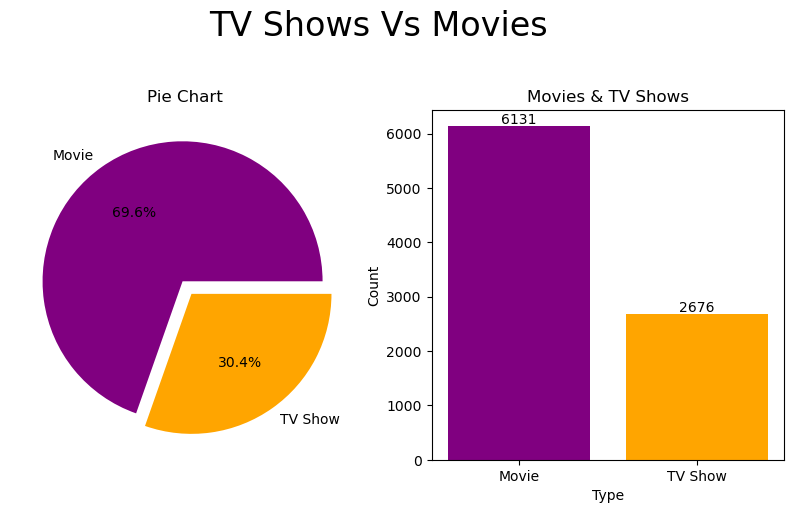

```python
# TV Shows Vs Movies in a Graphical Representation
df_type = df["type"].value_counts()
x = df_type.index
y = df_type
fig = plt.figure (figsize= (10,10))
plt.subplot (2,2,1)
plt.pie(y,explode = (0.03, 0.08), labels = x, colors= ["purple", "orange"], autopct = "%.1f%%")
plt.title("Pie Chart")

plt.subplot (2,2,2)
height = plt.bar(x,y, color = ["purple" ,"orange"])
for bar in height:
    yval = bar.get_height()
    plt.text(bar.get_x() + bar.get_width()/2, yval, str(yval), ha = "center", va = "bottom")
plt.title("Movies & TV Shows")
plt.xlabel("Type")
plt.ylabel("Count")
plt.suptitle("TV Shows Vs Movies " , fontsize = 24)
plt.show()
```